# Time Series CW1

S Shah

2025-03-13

[Click here to go to the QMUL website](https://www.qmul.ac.uk)

## Exploring a Time Series Using Meta’s Prophet System

### 1. Using Prophet

Meta has released a time series forecasting system call **prophet**. This is a introductory look at the prophet system (and seeing how it compares with R).

```r
library(prophet)
library(astsa)

# Load the US Unemployment dataset
data(unemp)
```

*‘unemp’* is a time series. Use the `plot(decompose())` function to get a preview of the features of the time series in R. It will show the observed data,trend, seasonal and random components.

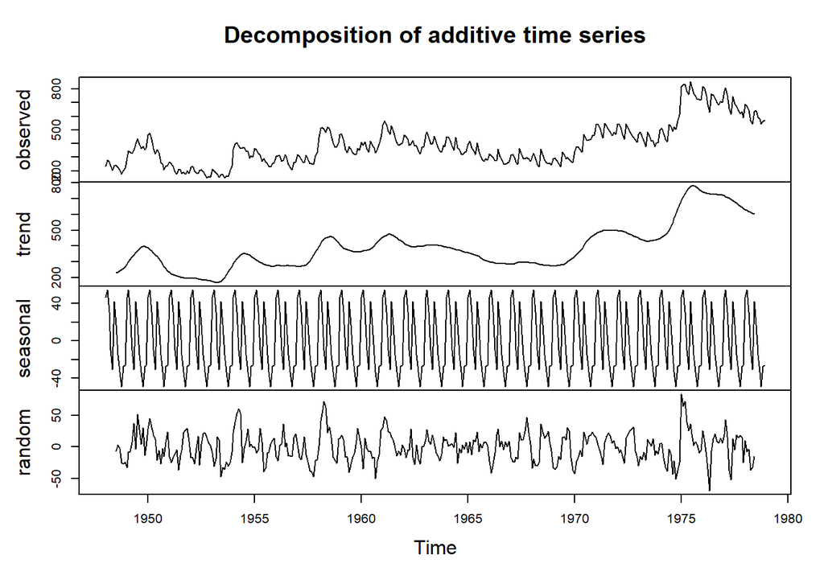

```r
plot(decompose(unemp))
```

Prophet requires the data to be in a **data frame** with two columns:

- ds: the time column
- y: the data column

Will need to load the library `zoo` or use the syntax `ds=zoo::as.yearmon()`

```r
Unemployment_dataframe = data.frame(ds=zoo::as.yearmon(time(unemp)),y=unemp)

head(Unemployment_dataframe)
```

```
##         ds     y
## 1 Jan 1948 235.1
## 2 Feb 1948 280.7
## 3 Mar 1948 264.6
## 4 Apr 1948 240.7
## 5 May 1948 201.4
## 6 Jun 1948 240.8
```

It would appear that the numbers are given as ’0000

**Fitting the Model**

Now we fit the model using `prophet()` This gives model with daily and weekly seasonality disabled.

```r
FittedUnemploymentModel = prophet::prophet(Unemployment_dataframe)
```

```
## Disabling weekly seasonality. Run prophet with weekly.seasonality=TRUE to override this.
```

```
## Disabling daily seasonality. Run prophet with daily.seasonality=TRUE to override this.
```

**Future Predictions**

we first create a future dataframe for a desired forecast period of 2 years using `make_future_dataframe()`

Then we use the `predict()` function for the forecast

```r
future = prophet::make_future_dataframe(FittedUnemploymentModel,periods=24,freq="month")

forecast = predict(FittedUnemploymentModel,future)
```

Now we plot the forecasted results using `plot`

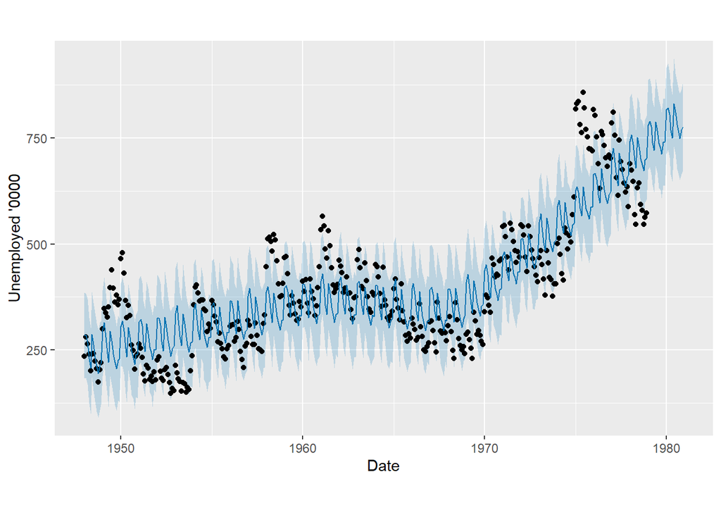

```r
plot(FittedUnemploymentModel,forecast, xlab="Date",ylab="Unemployed '0000")
```

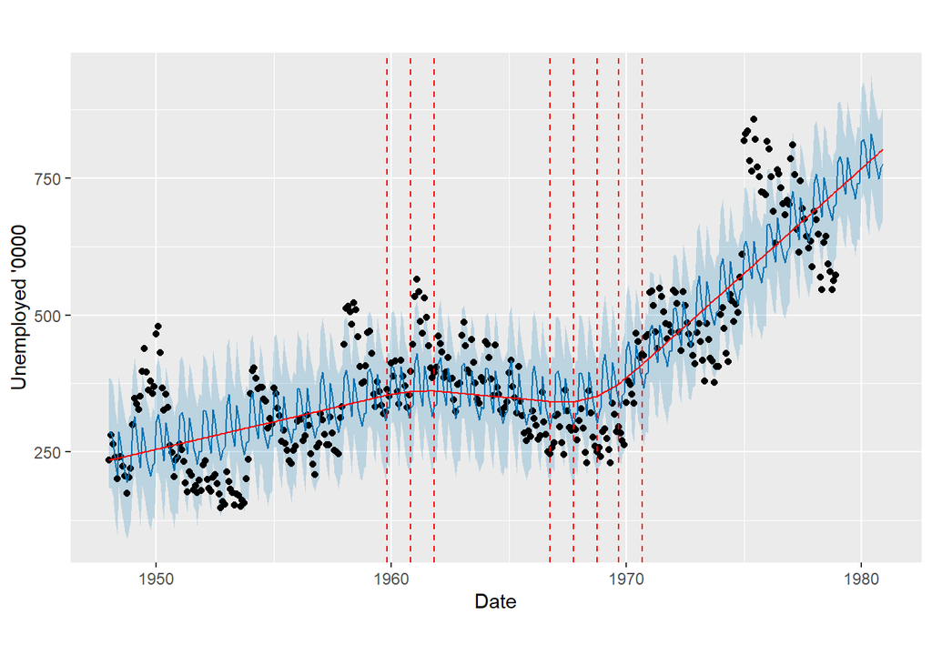

```r
## Can visualise it better by seeing where there are changes in trajectory
plot(FittedUnemploymentModel, forecast,xlab="Date",ylab="Unemployed '0000") + add_changepoints_to_plot(FittedUnemploymentModel)
```

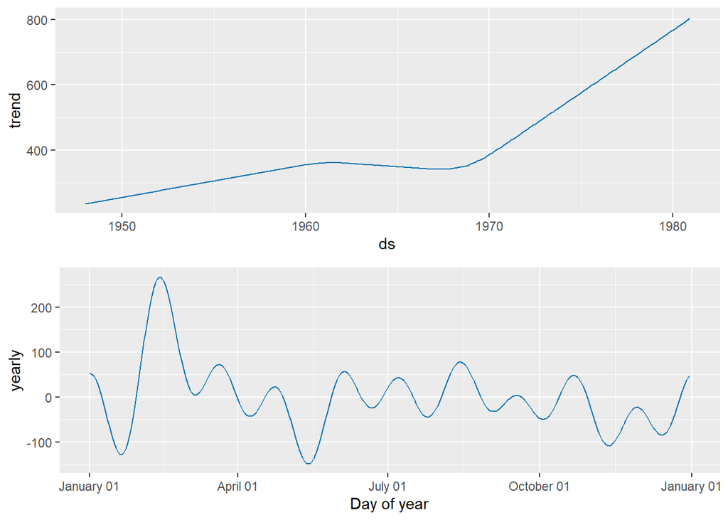

```r
## Plotting the forecasted components to see the forecast broken down into trend and yearly seasonality
prophet_plot_components(FittedUnemploymentModel, forecast)
```

Can see an overall upward trend in the numbers of unemployed, with a slight dip in the 1960s. The rate of unemployment increased faster in the 1970s - possibly due to the Oil Crisis and recession.

**Prediction for a longer period - 5 years**

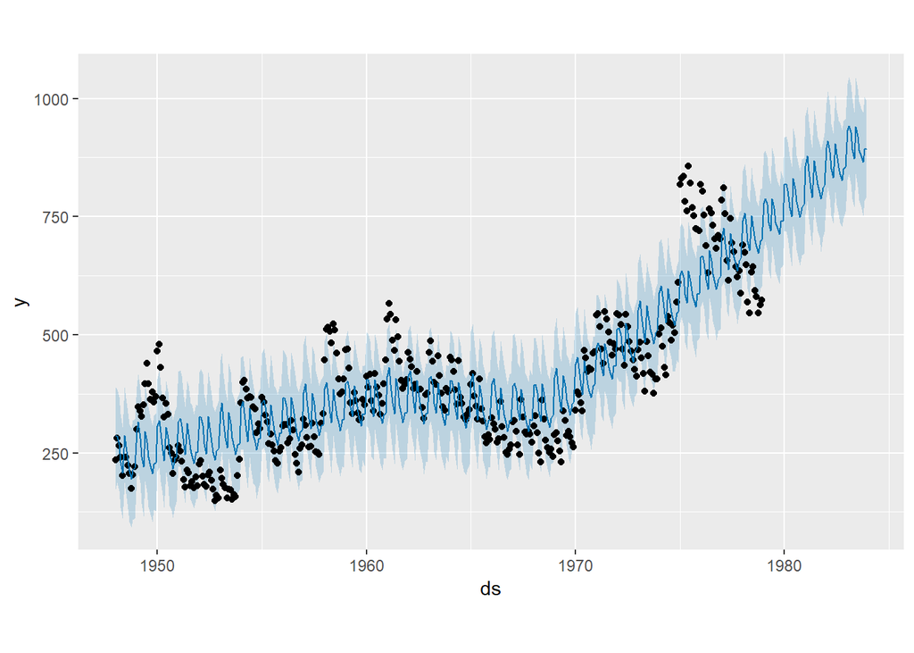

```r
futurelonger = prophet::make_future_dataframe(FittedUnemploymentModel,periods=60,freq="month")
forecastlonger = predict(FittedUnemploymentModel,futurelonger)
plot(FittedUnemploymentModel,forecastlonger)
```

### 2. Analysing Components

Now we analyse trends, seasonality and look at detrending and deseasonalizing

**Trend**

Need the `library(dplyr)` To see the trend

```r
library(dplyr)
```

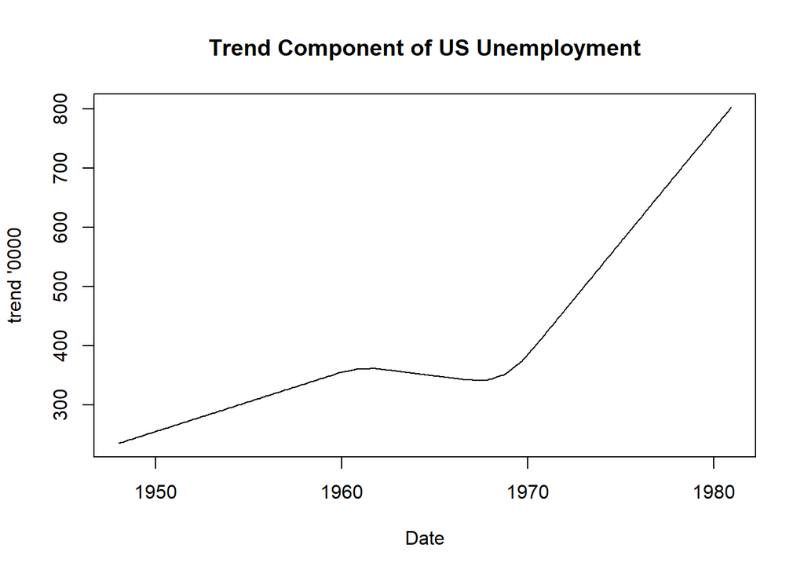

```r
trend = forecast %>% select(ds,trend)
plot(trend$ds,trend$trend,type="l",xlab="Date",ylab="trend '0000",main="Trend Component of US Unemployment")
```

**Seasonality**

To see the seasonality. *NOTE*: Prophet classifies seasonality as yearly, so use that in the syntax

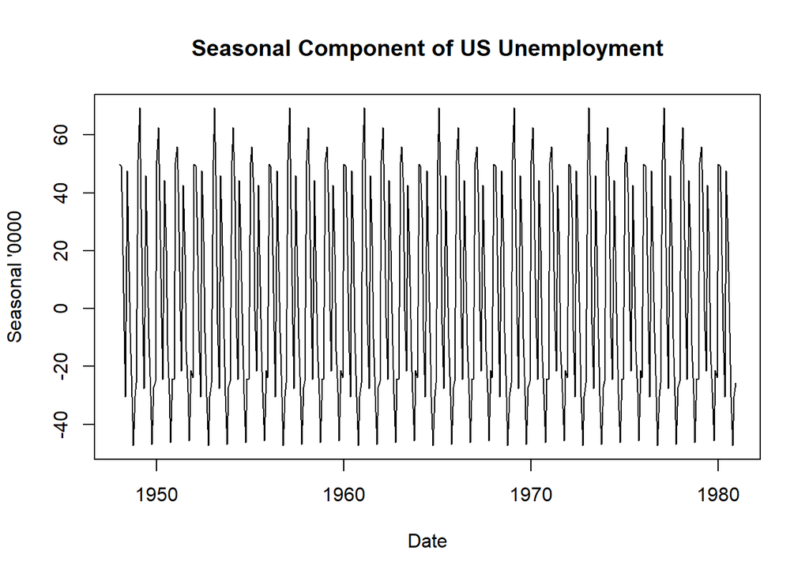

```r
library(dplyr)
seasonality = forecast %>% select(ds,yearly)
plot(seasonality$ds,seasonality$yearly,type="l",xlab="Date",ylab="Seasonal '0000",main="Seasonal Component of US Unemployment")
```

### 3. Linear Rgression

Run a linear regression using `lm()` to model the growth in the series and plot

```r
linear_model <- lm(y ~ ds, data = Unemployment_dataframe)
summary(linear_model)
```

```
##
## Call:
## lm(formula = y ~ ds, data = Unemployment_dataframe)
##
## Residuals:
##     Min      1Q  Median      3Q     Max
## -234.32  -72.71  -10.25   63.84  318.77
##
## Coefficients:
##               Estimate Std. Error t value Pr(>|t|)
## (Intercept) -2.343e+04  1.259e+03  -18.61   <2e-16 ***
## ds           1.213e+01  6.413e-01   18.92   <2e-16 ***
## ---
## Signif. codes:  0 '***' 0.001 '**' 0.01 '*' 0.05 '.' 0.1 ' ' 1
##
## Residual standard error: 110.7 on 370 degrees of freedom
## Multiple R-squared:  0.4917, Adjusted R-squared:  0.4903
## F-statistic: 357.9 on 1 and 370 DF,  p-value: < 2.2e-16
```

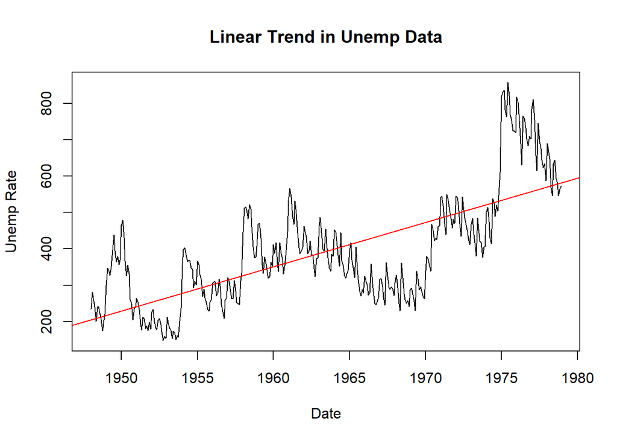

```r
## Plot
plot(Unemployment_dataframe$ds, Unemployment_dataframe$y, type = "l", main = "Linear Trend in Unemp Data", xlab = "Date", ylab = "Unemp Rate")
abline(linear_model, col = "red")
```

The `summary(linear_model)` output provides details such as the slope and intercept of the model.

Regression line suggest overall upward trend in unemployment. It would appear that the model oversimplifies the data.

### 4. Transformations of the Data to Stabilise Variance

We will try the log transformation. To obtain the detrended data, first order differencing operator $\nabla$ is applied to the transformed data.

We use the seasonal differencing operator $\nabla_{12}$ on the detrended data

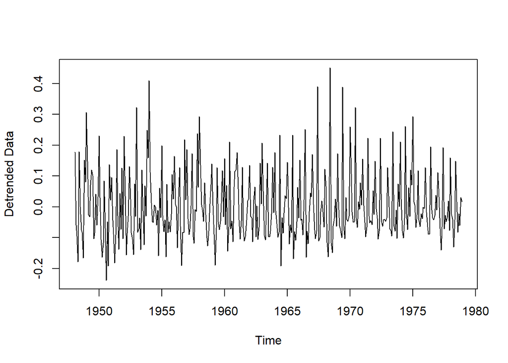

```r
logUnemployemnt_dataframe=log(Unemployment_dataframe$y)

## To obtain detrended data

difflogUnemployemnt_dataframe=diff(logUnemployemnt_dataframe)


plot(difflogUnemployemnt_dataframe, ylab="Detrended Data")
```

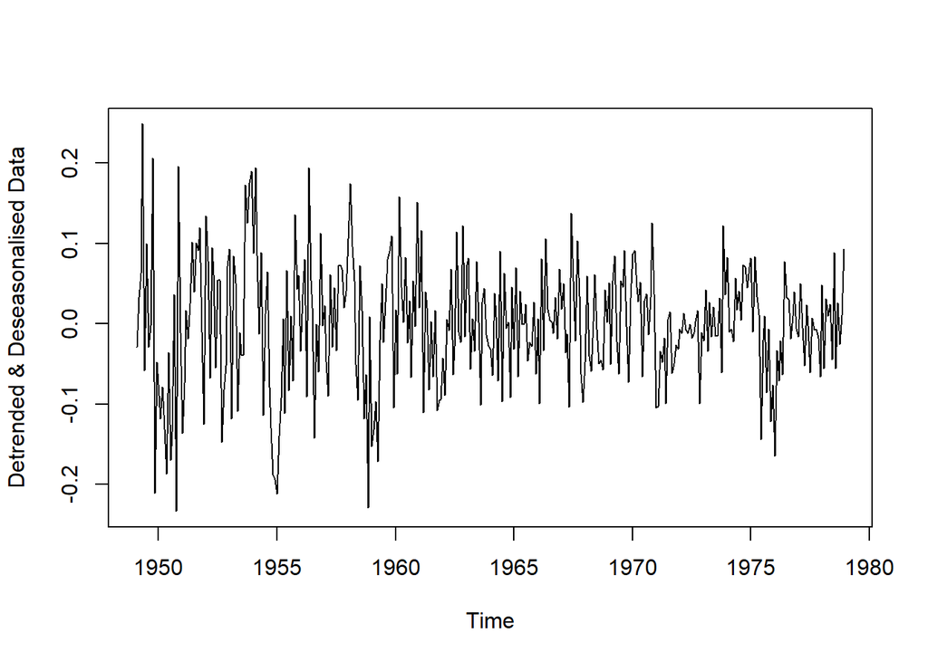

```r
## Deseasonalised data

diffdifflogUnemployemnt_dataframe=diff(difflogUnemployemnt_dataframe,12)

plot(diffdifflogUnemployemnt_dataframe, ylab="Detrended & Deseasonalised Data")
```

The application of the first differencing operator appears to remove the trend. Most of the seasonality is also taken care off by the lag operator. These adjustments provide insight into the residual behaviours.

### 5. Holt-Winters Exponential Smoothing

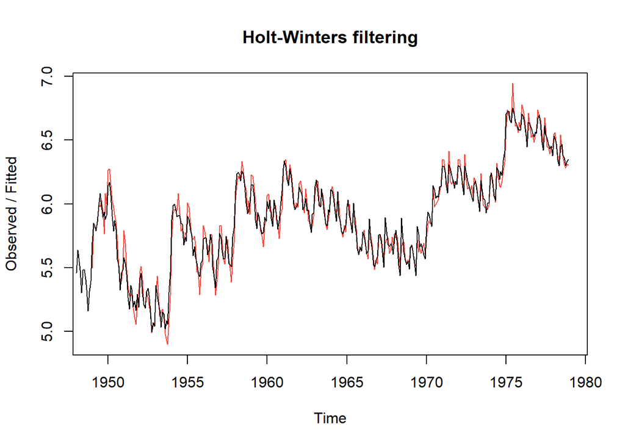

```r
hw=HoltWinters(logUnemployemnt_dataframe)
plot(hw)
```

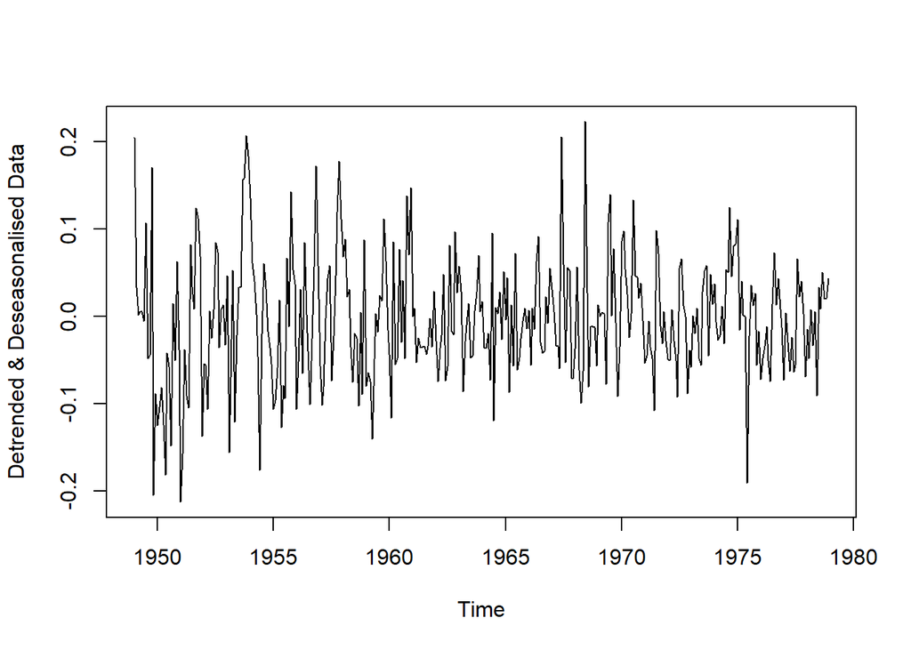

```r
## The detrended and deseasonalised data can be plotted

detrenddeseasonhw = logUnemployemnt_dataframe - hw$fitted[,1]
plot(detrenddeseasonhw,ylab="Detrended & Deseasonalised Data")
```

Not much difference between logarithmic smoothing and Holt-Winters Smoothing

### Holt-Winters vs Prophet

To compare Holt-Winters with Prophet, apply Holt-Winters using the `forecast` package on the same data

```r
library(forecast)
```

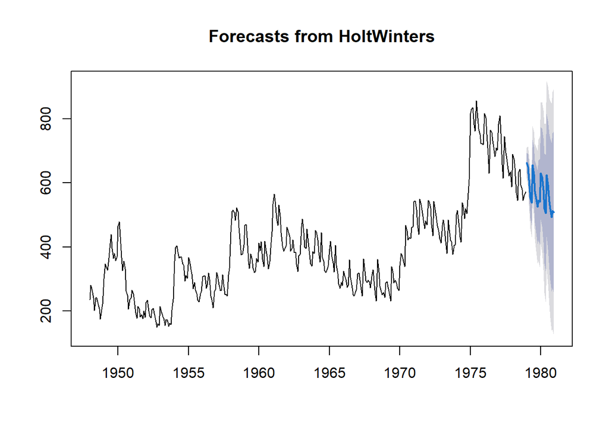

```r
hw_model = HoltWinters(unemp)
hw_forecast = forecast(hw_model, h = 24)
plot(hw_forecast)
```

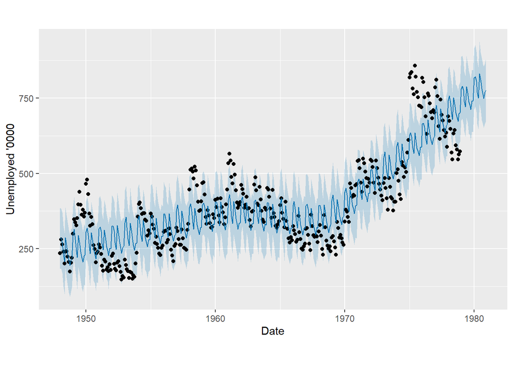

```r
## forecast from prophet
plot(FittedUnemploymentModel,forecast, xlab="Date",ylab="Unemployed '0000")
```

### 6. Summary

This provides an introductory analysis of a time series using Meta’s Prophet system. It covers data preparation, model fitting, future predictions, trends and seasonality, linear regression, transformations to stabilize variance. It also looks at Holt-Winters exponential smoothing, and comparison with Prophet forecasting.